# Principal component analysis: breast tumours

How many factorial axes a dataset really needs, how to read them, and what a supplementary variable is for.

The other vignettes are listed by `vignette (package = "fdm2id")`; they use the same handful of functions on other data, and can be read in any order.

```r
library (fdm2id)
```

# The data

A database on breast cancer, built in 1992 by Dr W. H. Wolberg at the University of Wisconsin. Of the 699 patients, 458 carried a benign tumour and 241 a malignant one. Each tumour is described by nine criteria (size, shape of the cells, and so on), each graded from 1 to 10.

Sixteen records have a missing value, all of them on `Bare.nuclei`. Rather than dropping those patients, the value is predicted from the eight other criteria and rounded back to the 1–10 scale – a regression used as an imputation, which is the first thing the package’s `LINREG` is good for here.

```r
library (mlbench)
data (BreastCancer)
BreastCancer = BreastCancer [, -1]
BreastCancer [, -10] = lapply (BreastCancer [, -10], function (x) as.numeric (as.character (x)))
names (which (colSums (is.na (BreastCancer)) > 0))
```

```
#> [1] "Bare.nuclei"
```

```r
train = BreastCancer [!is.na (BreastCancer$Bare.nuclei), ]
BreastCancer [is.na (BreastCancer$Bare.nuclei), 6] =
  round (predict (LINREG (train [, -c (6, 10)], train [, 6]),
                  BreastCancer [is.na (BreastCancer$Bare.nuclei), -6]))
summary (BreastCancer)
```

```
#>   Cl.thickness      Cell.size        Cell.shape     Marg.adhesion
#>  Min.   : 1.000   Min.   : 1.000   Min.   : 1.000   Min.   : 1.000
#>  1st Qu.: 2.000   1st Qu.: 1.000   1st Qu.: 1.000   1st Qu.: 1.000
#>  Median : 4.000   Median : 1.000   Median : 1.000   Median : 1.000
#>  Mean   : 4.418   Mean   : 3.134   Mean   : 3.207   Mean   : 2.807
#>  3rd Qu.: 6.000   3rd Qu.: 5.000   3rd Qu.: 5.000   3rd Qu.: 4.000
#>  Max.   :10.000   Max.   :10.000   Max.   :10.000   Max.   :10.000
#>   Epith.c.size     Bare.nuclei      Bl.cromatin     Normal.nucleoli
#>  Min.   : 1.000   Min.   : 1.000   Min.   : 1.000   Min.   : 1.000
#>  1st Qu.: 2.000   1st Qu.: 1.000   1st Qu.: 2.000   1st Qu.: 1.000
#>  Median : 2.000   Median : 1.000   Median : 3.000   Median : 1.000
#>  Mean   : 3.216   Mean   : 3.528   Mean   : 3.438   Mean   : 2.867
#>  3rd Qu.: 4.000   3rd Qu.: 6.000   3rd Qu.: 5.000   3rd Qu.: 4.000
#>  Max.   :10.000   Max.   :10.000   Max.   :10.000   Max.   :10.000
#>     Mitoses             Class
#>  Min.   : 1.000   benign   :458
#>  1st Qu.: 1.000   malignant:241
#>  Median : 1.000
#>  Mean   : 1.589
#>  3rd Qu.: 1.000
#>  Max.   :10.000
```

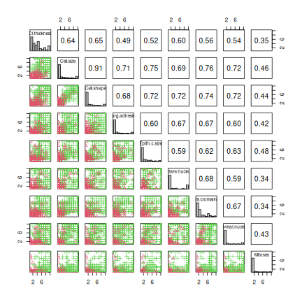

```r
plotdata (BreastCancer)
```

# Question 1. How many factorial axes are needed?

```r
pca = PCA (BreastCancer, quali.sup = 10, scale.unit = TRUE)
kaiser (pca)
```

```
#> [1] 1
```

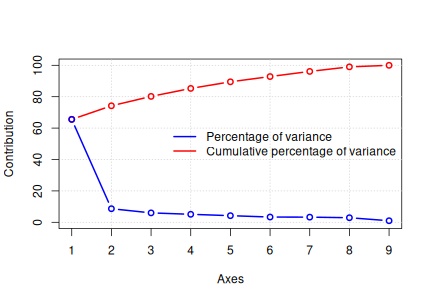

```r
plot (pca, type = "eig")
```

**Answer.** *Both Kaiser’s rule and the elbow of the scree plot say that a single factorial axis is enough.* It carries 65.6% of the variance on its own, the second one 8.6%.

# Question 2. How should the first two axes be read?

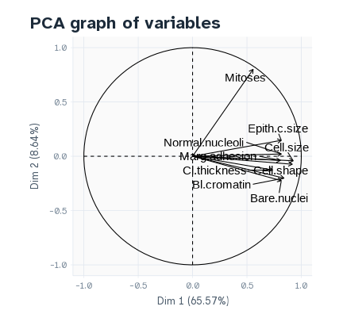

```r
plot (pca, type = "cor")
```

**Answer.** *On the correlation circle, every variable is strongly tied to the first axis. The second one depends mainly on `Mitoses`* – the only variable whose coordinate on it is large.

```r
round (pca$var$coord [, 1:2], 2)
```

```
#>                 Dim.1 Dim.2
#> Cl.thickness     0.73 -0.13
#> Cell.size        0.93 -0.04
#> Cell.shape       0.92 -0.07
#> Marg.adhesion    0.81 -0.04
#> Epith.c.size     0.82  0.15
#> Bare.nuclei      0.82 -0.22
#> Bl.cromatin      0.84 -0.20
#> Normal.nucleoli  0.82  0.02
#> Mitoses          0.56  0.80
```

# Question 3. What can be said about the two groups of tumours?

The class was declared as a supplementary variable, so it played no part in building the axes. Nothing stops us from colouring the individuals by it afterwards – that is the whole point of declaring it supplementary.

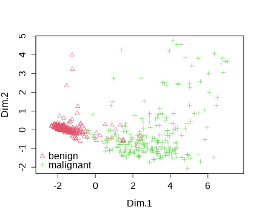

```r
plotdata (pca$ind$coord [, 1:2], BreastCancer [, 10], type = "scatter")
```

**Answer.** *The benign tumours form a very homogeneous group, the malignant ones a much more scattered one. The position on the first principal axis is related to the type of the tumour: the higher the value, the more likely the tumour is malignant.*

```r
round (tapply (pca$ind$coord [, 1], BreastCancer [, 10], mean), 2)
```

```
#>    benign malignant
#>     -1.57      2.99
```

```r
round (tapply (pca$ind$coord [, 1], BreastCancer [, 10], sd), 2)
```

```
#>    benign malignant
#>      0.69      1.60
```

The two means are far apart, and the standard deviation of the malignant group is more than twice that of the benign one.